# EDLD 610: Lab 5

Cameron Kay and Ashley Miller

2/13/2019

### Part 1 (Ash)

#### 1) In a new code chunk (separate from the chunk you used to import the data) reproduce the plot.

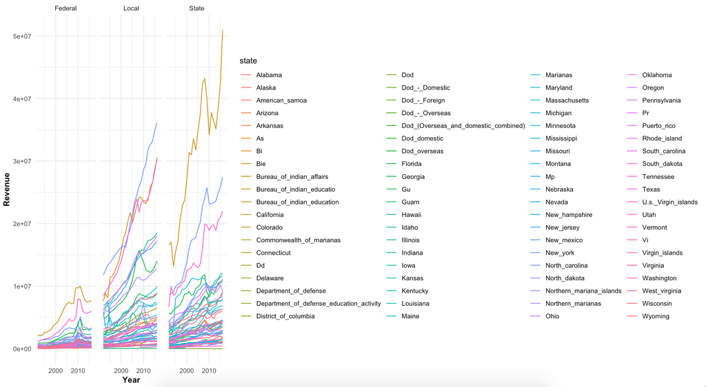

```r
states_ash <- states_data %>%
  select(state, year, federal_revenue:local_revenue) %>%
  rename(Federal = federal_revenue,
         State = state_revenue,
         Local = local_revenue) %>%
  mutate(state = stringr::str_to_title(state)) %>%
  gather(key = type, value = revenue, Federal:Local) %>%
  group_by(state, year, type) %>%
  summarise(mean_revenue = mean(revenue, na.rm = TRUE))

plot1 <- ggplot(states_ash, aes(x = year, y = mean_revenue, color = state)) +
  geom_line() +
  facet_wrap(~type) +
  theme_minimal() +
  theme(axis.title = element_text(face = "bold")) +
  labs(y = "Revenue",
       x = "Year")
```

#### 2) Briefly Explain (outside the code chunk) a few things that could be done to improve the plot, and why. I’m less interested in the code here and more interested in why you feel the changes would improve the plot.

- If our colleague wants to explore differences in revenue over time by *state*, I’m unsure why they would include the Department of Defense, Bureau of Indian Affairs, Virgin Islands (as well as US Virgin Islands?), Guam, etc. Not only that, but I have no idea what the following names refer to: As, Bl, Bie, Dd, Gu, Mp, Pr, and Vi. I would filter the dataset to only include the 50 US states.
- I’d also consider grouping/coloring the states by region (e.g., northwest, southwest, midwest, northeast, southest).
- Alternatively, we could just highlight and label the few states that stick out from the rest in each graph.
- I’d transform the y-axis labels to enhance clarity.
- I’d also ajust the x-axis to include a label every 5 years (e.g., 1995, 2000, 2005, 2010, 2015).

#### 3) In a new code chunk, make at least 3 revisions to the plot that you suggested above.

```r
#load data including info on state regions
region <- import("https://raw.githubusercontent.com/cphalpert/census-regions/master/us%20census%20bureau%20regions%20and%20divisions.csv") %>%
  mutate(State = stringr::str_to_title(State)) %>%
  rename(state = State)

#Identify names to exclude in state column
exclude <- c("American_samoa", "As", "Bi", "Bie", "Bureau_of_indian_affairs", "Bureau_of_indian_educatio", "Bureau_of_indian_education", "Commonwealth_of_marianas", "Dd", "Department_of_defense", "Department_of_defense_education_activity", "District_of_columbia", "Dod", "Dod_-_Domestic", "Dod_-_Foreign", "Dod_-_Overseas", "Dod_(Overseas_and_domestic_combined)", "Dod_domestic", "Dod_overseas", "Gu", "Guam", "Marianas", "Mp", "Northern_mariana_islands", "Northern_marianas", "Pr", "Puerto_rico", "U.s._Virgin_islands", "Vi", "Virgin_islands")

#filter out anything not a US state
states_ash %<>%
  filter(!state %in% exclude)

#Let's make sure our state IDs match prior to joining
#levels(as.factor(states_ash$state))

states_ash[which(states_ash$state == "New_hampshire"), "state"] <- "New Hampshire"
states_ash[which(states_ash$state == "New_jersey"), "state"] <- "New Jersey"
states_ash[which(states_ash$state == "New_mexico"), "state"] <- "New Mexico"
states_ash[which(states_ash$state == "New_york"), "state"] <- "New York"
states_ash[which(states_ash$state == "North_carolina"), "state"] <- "North Carolina"
states_ash[which(states_ash$state == "North_dakota"), "state"] <- "North Dakota"
states_ash[which(states_ash$state == "Rhode_island"), "state"] <- "Rhode Island"
states_ash[which(states_ash$state == "South_carolina"), "state"] <- "South Carolina"
states_ash[which(states_ash$state == "South_dakota"), "state"] <- "South Dakota"
states_ash[which(states_ash$state == "West_virginia"), "state"] <- "West Virginia"

#join datasets
state_join <- left_join(states_ash, region, by = "state")
```

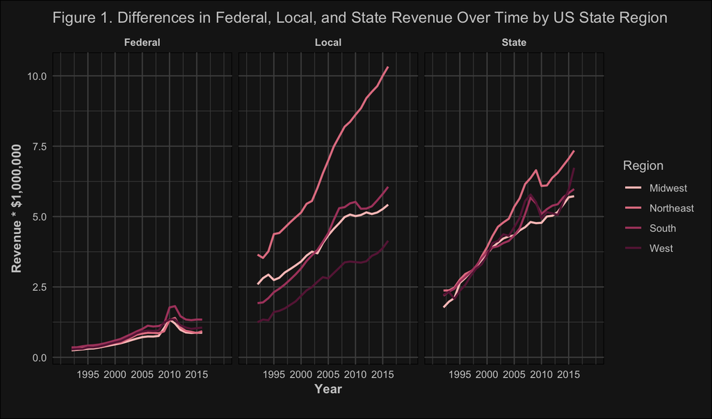

```r
#############################################################
#Plot 1: revenue across time broken down by region within US#
#############################################################

fig1 <- state_join %>%
  group_by(Region, year, type) %>%
  summarize(m_rev = mean(mean_revenue)) %>%
  mutate(mean_revenue_mil = m_rev/1000000) %>%
  select(-m_rev) %>%
  ggplot(aes(x = year, y = mean_revenue_mil, color = Region)) +
    geom_line(size = 0.85) +
    facet_wrap(~type) +
    scale_color_carto_d(palette = "Burg") +
    theme_minimal() +
    theme(axis.title = element_text(face = "bold"),
          strip.text = element_text(face = "bold")) +
    labs(title = "Figure 1. Differences in Federal, Local, and State Revenue Over Time by US State Region",
         y = "Revenue * $1,000,000",
         x = "Year") +
    scale_x_continuous(breaks = c(1995, 2000, 2005, 2010, 2015),
                       label = c("1995", "2000", "2005", "2010", "2015"),
                       limits = c(1990, 2020))


fig1 + theme(panel.grid.major = element_line(colour = "gray30"),
          panel.grid.minor = element_line(colour = "gray30"),
          axis.text = element_text(colour = "gray80"),
          axis.text.x = element_text(colour = "gray80"),
          axis.text.y = element_text(colour = "gray80"),
          axis.title = element_text(colour = "gray80"),
          legend.text = element_text(colour = "gray80"),
          legend.title = element_text(colour = "gray80"),
          strip.text = element_text(colour = "gray80"),
          panel.background = element_rect(fill = "gray10"),
          plot.background = element_rect(fill = "gray10"),
          legend.background = element_rect(fill = NA, color = NA),
          plot.margin = margin(10, 10, b = 20, 10),
          plot.caption = element_text(colour = "gray80", vjust = 1),
          plot.title = element_text(colour = "gray80"))
```

### Part 2 (Cam)

#### 1) Help your colleague reproduce the plot to highlight the five highest and lowest revenue states, after accounting for enrollment. Make any other modifications you feel would help aid communication.

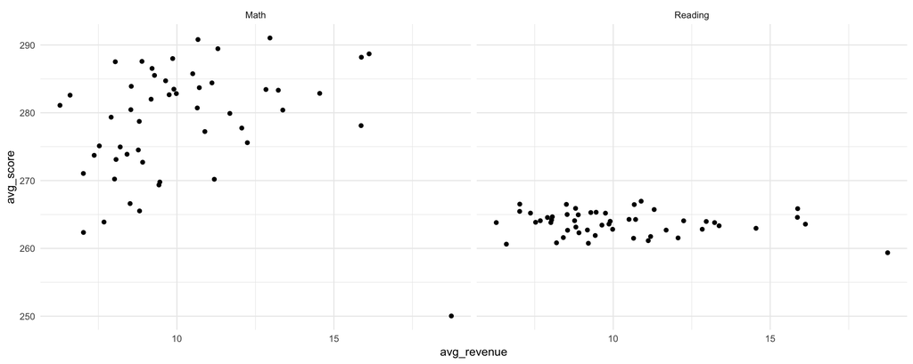

```r
# prepare data
cam_data <- states_data %>%
  mutate(rev_enr = total_revenue / enroll) %>%
  group_by(state) %>%
  summarize(avg_revenue = mean(rev_enr,             na.rm = TRUE),
            avg_math    = mean(avg_math_8_score,    na.rm = TRUE),
            avg_reading = mean(avg_reading_8_score, na.rm = TRUE)) %>%
  filter(!is.na(avg_revenue),
         !is.na(avg_math),
         !is.na(avg_reading)) %>%
  gather(key   = "content",
         value = "avg_score",
         avg_math:avg_reading) %>%
  mutate(content = gsub("avg_", "", content),
         content = stringr::str_to_title(content),
         state   = gsub("_", " ", state),
         state   = stringr::str_to_title(state),
         state   = gsub("Of", "of", state)) %>%
  arrange(state)

# reproduce plot
ggplot(cam_data, aes(x = avg_revenue, y = avg_score)) +
  geom_point() +
  facet_wrap(~content) +
  theme_minimal()
```

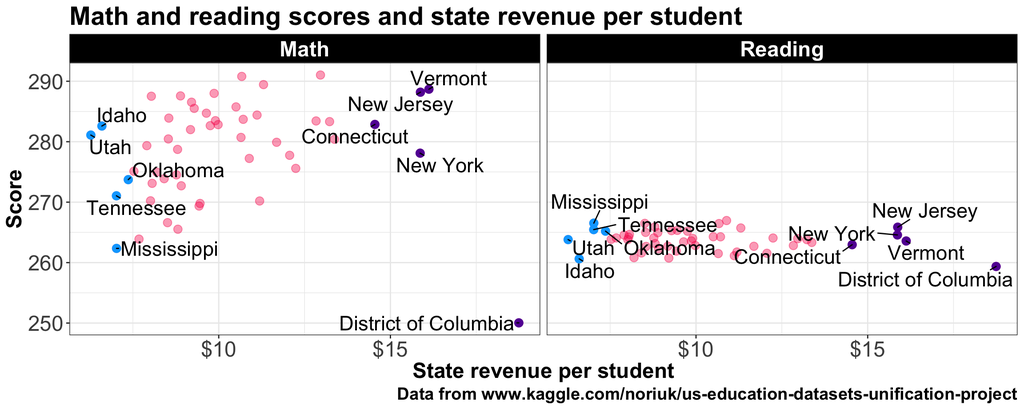

```r
# improve plot
ggplot(cam_data, aes(x = avg_revenue, y = avg_score)) +
  geom_point(alpha = .4, color = "#f72257", size = 3) +
  facet_wrap(~content) +
  geom_point(data = slice(arrange(cam_data, desc(avg_revenue)), 1:10),
             color = "#6400a3", size = 3) +
  geom_text_repel(data  = slice(arrange(cam_data, desc(avg_revenue)), 1:10),
                aes(label = state), size = 6,
              min.segment.length = 0) +
  geom_point(data = slice(arrange(cam_data, avg_revenue), 1:10),
             color = "#00a9ff", size = 3) +
  geom_text_repel(data  = slice(arrange(cam_data, avg_revenue), 1:10),
              aes(label = state), size = 6,
              min.segment.length = 0) +
  scale_x_continuous(labels = scales::dollar) +
  labs(title = "Math and reading scores and state revenue per student",
       y = "Score",
       x = "State revenue per student",
       caption = "Data from www.kaggle.com/noriuk/us-education-datasets-unification-project") +
  theme_bw() +
  theme(title = element_text(face = "bold", size = 18),
        axis.title.x = element_text(face = "bold", size = 18),
        axis.title.y = element_text(face = "bold", size = 18),
        strip.background = element_rect(fill = "black"),
        strip.text = element_text(face = "bold", color = "white", size = 18),
        axis.text = element_text(size = 18)
        )
```